# salary data

```python
import numpy as np
import pandas as pd
import seaborn as sns
import matplotlib.pyplot as plt
```

```python
df = pd.read_csv(r"C:\Users\kapil\OneDrive\Desktop\Salary_Data.csv")
df
```

|  | Age | Gender | Education Level | Job Title | Years of Experience | Salary |
| --- | --- | --- | --- | --- | --- | --- |
| 0 | 32.0 | Male | Bachelor's | Software Engineer | 5.0 | 90000.0 |
| 1 | 28.0 | Female | Master's | Data Analyst | 3.0 | 65000.0 |
| 2 | 45.0 | Male | PhD | Senior Manager | 15.0 | 150000.0 |
| 3 | 36.0 | Female | Bachelor's | Sales Associate | 7.0 | 60000.0 |
| 4 | 52.0 | Male | Master's | Director | 20.0 | 200000.0 |
| ... | ... | ... | ... | ... | ... | ... |
| 6699 | 49.0 | Female | PhD | Director of Marketing | 20.0 | 200000.0 |
| 6700 | 32.0 | Male | High School | Sales Associate | 3.0 | 50000.0 |
| 6701 | 30.0 | Female | Bachelor's Degree | Financial Manager | 4.0 | 55000.0 |
| 6702 | 46.0 | Male | Master's Degree | Marketing Manager | 14.0 | 140000.0 |
| 6703 | 26.0 | Female | High School | Sales Executive | 1.0 | 35000.0 |

6704 rows × 6 columns

```python
df.head(12)
```

|  | Age | Gender | Education Level | Job Title | Years of Experience | Salary |
| --- | --- | --- | --- | --- | --- | --- |
| 0 | 32.0 | Male | Bachelor's | Software Engineer | 5.0 | 90000.0 |
| 1 | 28.0 | Female | Master's | Data Analyst | 3.0 | 65000.0 |
| 2 | 45.0 | Male | PhD | Senior Manager | 15.0 | 150000.0 |
| 3 | 36.0 | Female | Bachelor's | Sales Associate | 7.0 | 60000.0 |
| 4 | 52.0 | Male | Master's | Director | 20.0 | 200000.0 |
| 5 | 29.0 | Male | Bachelor's | Marketing Analyst | 2.0 | 55000.0 |
| 6 | 42.0 | Female | Master's | Product Manager | 12.0 | 120000.0 |
| 7 | 31.0 | Male | Bachelor's | Sales Manager | 4.0 | 80000.0 |
| 8 | 26.0 | Female | Bachelor's | Marketing Coordinator | 1.0 | 45000.0 |
| 9 | 38.0 | Male | PhD | Senior Scientist | 10.0 | 110000.0 |
| 10 | 29.0 | Male | Master's | Software Developer | 3.0 | 75000.0 |
| 11 | 48.0 | Female | Bachelor's | HR Manager | 18.0 | 140000.0 |

- When apply df.head(12) it returns a new dataset that contains only the first 12 rows of the original DataFrame.

```python
df.describe()
```

|  | Age | Years of Experience | Salary |
| --- | --- | --- | --- |
| count | 6702.000000 | 6701.000000 | 6699.000000 |
| mean | 33.620859 | 8.094687 | 115326.964771 |
| std | 7.614633 | 6.059003 | 52786.183911 |
| min | 21.000000 | 0.000000 | 350.000000 |
| 25% | 28.000000 | 3.000000 | 70000.000000 |
| 50% | 32.000000 | 7.000000 | 115000.000000 |
| 75% | 38.000000 | 12.000000 | 160000.000000 |
| max | 62.000000 | 34.000000 | 250000.000000 |

- df.describe() is a DataFrame where the rows represent each of the statistics described above count, mean, std, min and max.

```python
df.info()
```

```
<class 'pandas.core.frame.DataFrame'>
RangeIndex: 6704 entries, 0 to 6703
Data columns (total 6 columns):
 #   Column               Non-Null Count  Dtype
---  ------               --------------  -----
 0   Age                  6702 non-null   float64
 1   Gender               6702 non-null   object
 2   Education Level      6701 non-null   object
 3   Job Title            6702 non-null   object
 4   Years of Experience  6701 non-null   float64
 5   Salary               6699 non-null   float64
dtypes: float64(3), object(3)
memory usage: 314.4+ KB
```

- The df.info() method in pandas provides a concise summary of the dataset, including information about the data types, non-null values and memory usage.

```python
df.isnull()
```

|  | Age | Gender | Education Level | Job Title | Years of Experience | Salary |
| --- | --- | --- | --- | --- | --- | --- |
| 0 | False | False | False | False | False | False |
| 1 | False | False | False | False | False | False |
| 2 | False | False | False | False | False | False |
| 3 | False | False | False | False | False | False |
| 4 | False | False | False | False | False | False |
| ... | ... | ... | ... | ... | ... | ... |
| 6699 | False | False | False | False | False | False |
| 6700 | False | False | False | False | False | False |
| 6701 | False | False | False | False | False | False |
| 6702 | False | False | False | False | False | False |
| 6703 | False | False | False | False | False | False |

6704 rows × 6 columns

- The df.isnull() method in pandas is used to identify missing values in a DataFrame.

```python
df.isnull().sum()
```

```
Age                    2
Gender                 2
Education Level        3
Job Title              2
Years of Experience    3
Salary                 5
dtype: int64
```

- The df.isnull().sum() expression is commonly used in pandas to calculate the total number of missing values in each column of a Dataset.

```python
cat_var=['Gender','Education Level','Job Title']
```

```python
for var in cat_var:
    df[var]=df[var].fillna(df[var].mode()[0])
```

- The code is a loop that iterates over each categorical variable in the list (cat_var).
- For each variable, it fills missing values with the most frequent value (mode) in that variable.
- This is a common strategy for handling missing values in categorical data.

```python
num_var=['Age','Years of Experience','Salary']
```

```python
for var in num_var:
    df[var]=df[var].fillna(df[var].median())
```

- The code is a loop that iterates over each numerical variable in the list (num_var).
- For each variable, it fills missing values with the median value of that variable.
- Using the median for imputation is a common strategy for handling missing values in numerical data.

```python
df.isnull().sum()
```

```
Age                    0
Gender                 0
Education Level        0
Job Title              0
Years of Experience    0
Salary                 0
dtype: int64
```

```python
df.head()
```

|  | Age | Gender | Education Level | Job Title | Years of Experience | Salary |
| --- | --- | --- | --- | --- | --- | --- |
| 0 | 32.0 | Male | Bachelor's | Software Engineer | 5.0 | 90000.0 |
| 1 | 28.0 | Female | Master's | Data Analyst | 3.0 | 65000.0 |
| 2 | 45.0 | Male | PhD | Senior Manager | 15.0 | 150000.0 |
| 3 | 36.0 | Female | Bachelor's | Sales Associate | 7.0 | 60000.0 |
| 4 | 52.0 | Male | Master's | Director | 20.0 | 200000.0 |

# Pie Plot

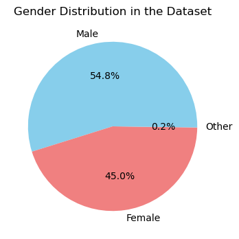

```python
gender_counts = df['Gender'].value_counts()
plt.figure(figsize=(4, 4))
plt.pie(gender_counts, labels=gender_counts.index, autopct='%1.1f%%', colors=['skyblue', 'lightcoral'])
plt.title('Gender Distribution in the Dataset')
plt.show()
```

- This code takes the gender distribution data from a dataset creates a pie chart using Matplotlib and then displays the chart with labels.
- The pie chart visually represents the distribution of genders in the dataset.

# Hist Plot

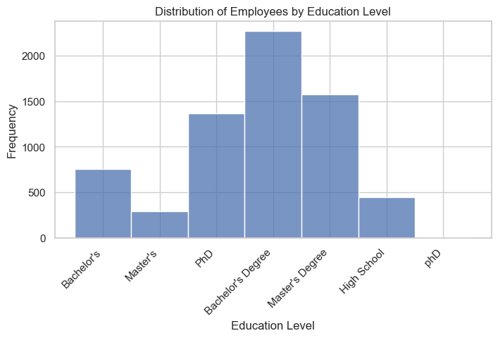

```python
plt.figure(figsize=(8, 4))
sns.histplot(data=df, x='Education Level', bins=range(len(df['Education Level'].unique()) + 1), discrete=True, palette='Set3')
plt.title('Distribution of Employees by Education Level')
plt.xlabel('Education Level')
plt.ylabel('Frequency')
plt.xticks(rotation=45, ha='right')
plt.show()
```

- A histogram plot where 'Education Level' is on the x-axis and the y-axis represents the frequency of each education level.

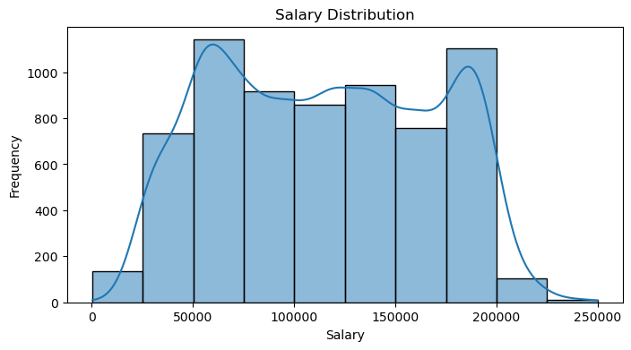

```python
plt.figure(figsize=(8, 4))
sns.histplot(df['Salary'], bins=10, kde=True)
plt.title('Salary Distribution')
plt.xlabel('Salary')
plt.ylabel('Frequency')
plt.show()
```

- This code creates a histogram of the salary distribution using Seaborn and Matplotlib.
- The histogram provides insights into the distribution of salary values in the dataset.
- The resulting plot is displayed with appropriate axis labels and a title.

# Box Plot

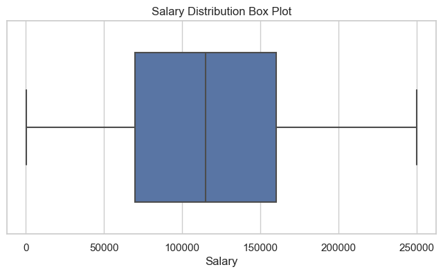

```python
plt.figure(figsize=(8, 4))
sns.boxplot(x='Salary', data=df, orient='h', width=0.7)
plt.title('Salary Distribution Box Plot')
plt.xlabel('Salary')
plt.show()
```

- This code creates a horizontal box plot of the salary distribution using Seaborn and Matplotlib.
- A box plot provides a visual summary of the distribution of a dataset.
- The resulting plot is displayed with an appropriate title, x-axis label, and figure size.

# Scatter Plot

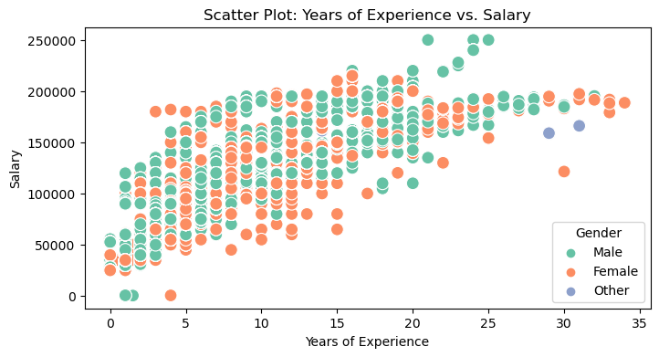

```python
plt.figure(figsize=(8, 4))
sns.scatterplot(x='Years of Experience', y='Salary', data=df, hue='Gender', palette='Set2', s=100)
plt.title('Scatter Plot: Years of Experience vs. Salary')
plt.xlabel('Years of Experience')
plt.ylabel('Salary')
plt.legend(title='Gender')
plt.show()
```

- This code creates a scatter plot to visualize the relationship between "Years of Experience" and "Salary" in a dataset.
- The points are differentiated by gender, and the plot includes a legend, title, and axis labels for better interpretation.

# Line Plot

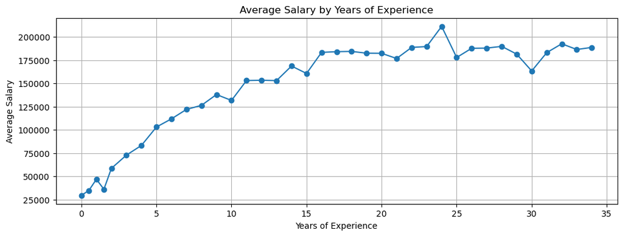

```python
average_salary_by_experience = df.groupby('Years of Experience')['Salary'].mean().reset_index()
average_salary_by_experience
plt.figure(figsize=(12, 4))
plt.plot(average_salary_by_experience['Years of Experience'], average_salary_by_experience['Salary'], marker='o')
plt.title('Average Salary by Years of Experience')
plt.xlabel('Years of Experience')
plt.ylabel('Average Salary')
plt.grid()
plt.show()
```

- This code calculates the average salary for each level of experience and visualizes the trend using a line plot.
- The resulting plot includes a title, axis labels, and a grid for better interpretation.